# Intégrer des résultats de tests statistiques à des graphiques

#### 2. Axes coupés ou non?

Si vous avez des données numériques avec des valeurs très éloignées de zéro il peut être tentant de ne pas faire commencer l’axe y à zéro mais plus proche de vos valeurs. Attention, cela peut cependant changer la conclusion!

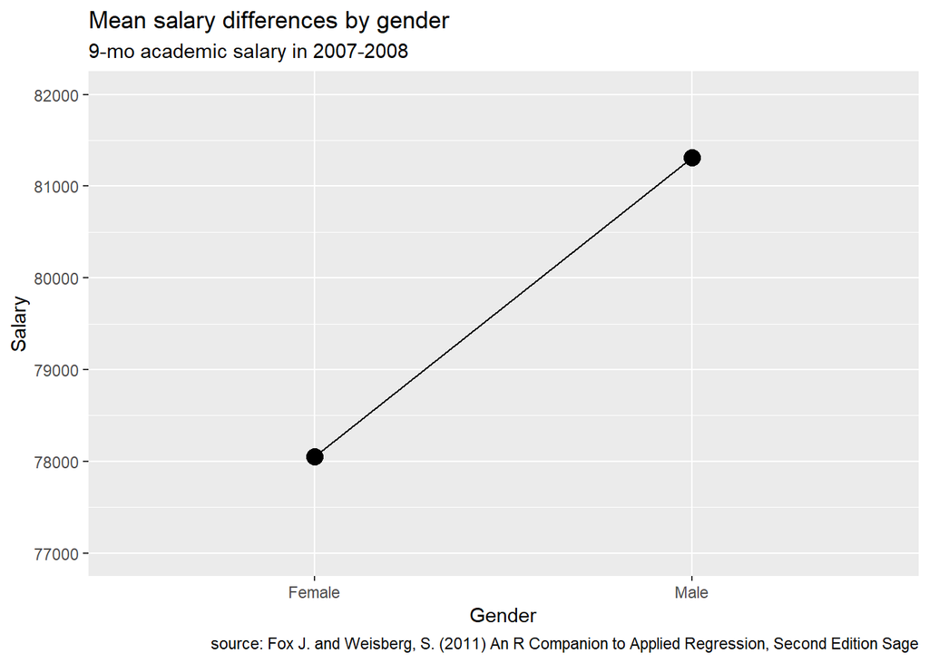

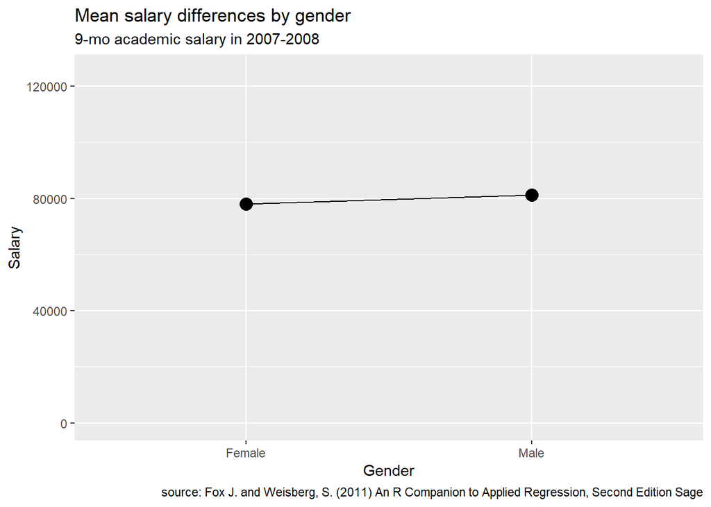

[source des images](https://rkabacoff.github.io/datavis/Advice.html)

De manière générale:

- Si vous utilisez des barplots ou des points avec différentes catégories à comparer, faites commencer l’axe y à zéro.
- Si vous utilisez des lignes (comme dans le cas de séries chronologiques), il n’est pas nécessaire de faire commencer l’axe des y à zéro. En effet ce type de graphique permet de montrer l’évolution d’une observation par exemple au cours du temps. Alors que les barplots sont utilisés pour montrer la différence entre deux (ou plusieurs) groupes

Si vous avez des données numériques avec certains points très éloignés des autres il peut être tentant de couper l’axe y entre les groupes de points. Ne le faites jamais!! Il existe d’autres alternatives comme par exemple utiliser une échelle logarithmique.

## Comment bien faire ressortir le message des graphiques

Maintenant que nous avons vu les erreurs à éviter quand nous créons des graphique, passons aux méthodes permettant de bien faire ressortir le message des graphiques. Cela permettra de faciliter l’interprétation des graphique.

De manière générale, évitez de faire des graphiques trop compliqués avec des fioritures. Évitez la 3D, les axes doubles et les lignes de grille. Concentrez vous sur l’essentiel!

Voyons trois méthodes plus en détail:

#### 1. Ordonnez les données

Par défaut, R va ordonner les catégories de vos variable par ordre alphabétique. Sur excel, l’ordre des variable dans le tableau est utilisé. Cependant cet ordre n’est pas toujours optimal.

Vous pouvez changer l’ordre des catégories de vos variables sur R (nous verrons comment en séance 5). Voici quelques conseils pour bien choisir l’ordre dans lequel représenter les données.

- Si vous comparez des données pour un (ou des) mutant à un wild type, ou si vous comparez un (ou plusieurs) traitement à un contrôle, **commencez toujours par la référence**, c.a.d le wild type ou le contrôle.
- S’il n’y a pas de référence (wild type ou contrôle) et que vous voulez comparer différents conditions, dans ce cas **ordonnez vos catégories en fonction de leur valeur**, par exemple du plus grand au plus petit. Cela permettra facilement d’identifier les catégories avec les valeurs les plus grandes ou plus petites, ou les catégories avec des valeurs similaires. Voici un exemple d’un graphique avec des catégories non ordonnées, puis avec des catégories ordonnées. La version avec les catégories ordonnées est beaucoup plus facile à interpréter.

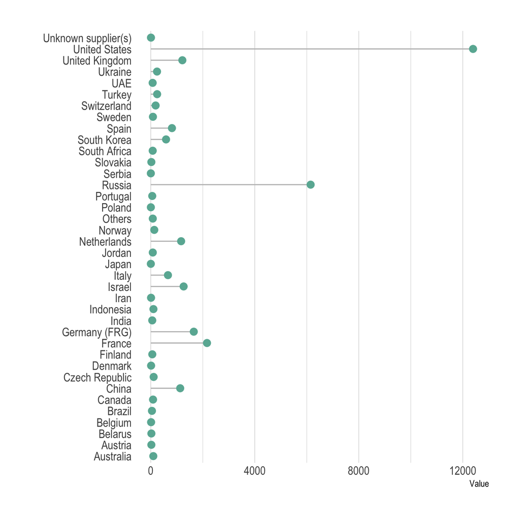

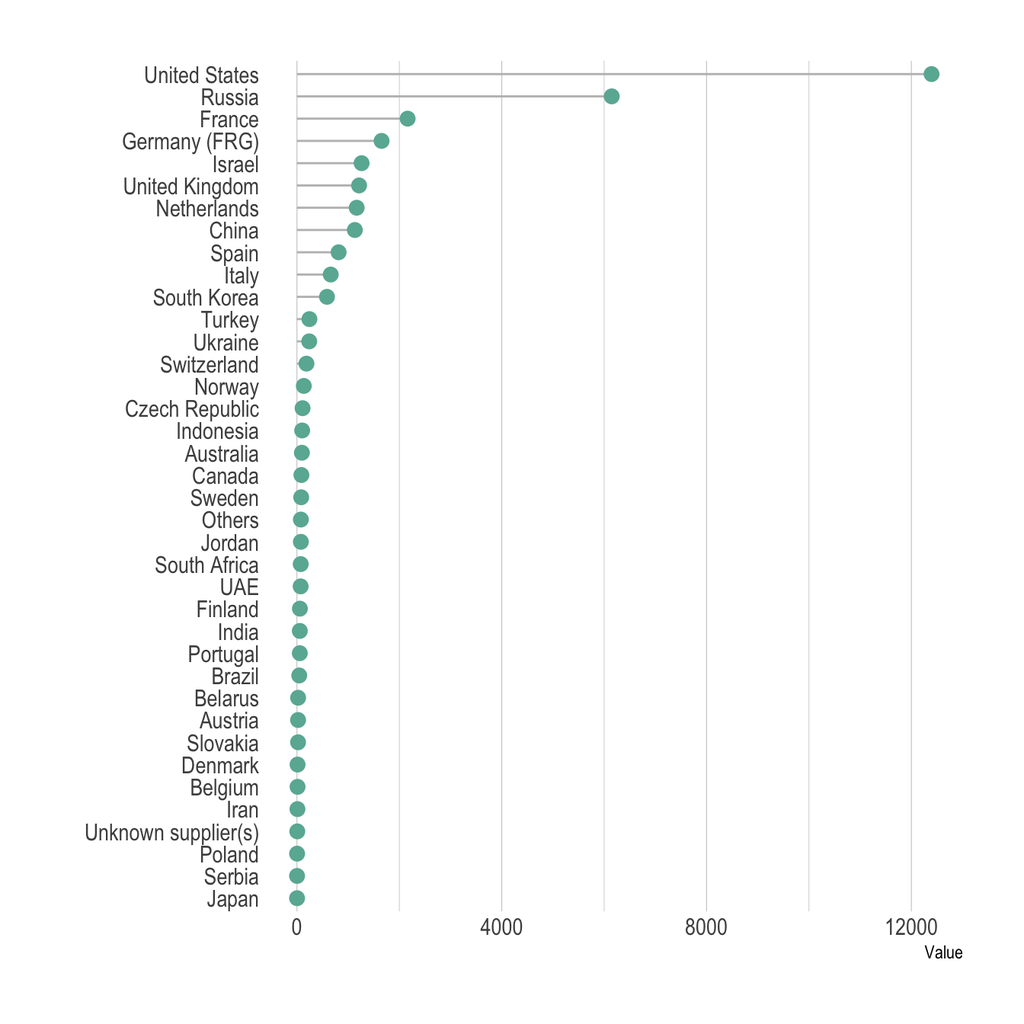

[source des images](https://www.data-to-viz.com/caveat/order_data.html)

#### 2. Évitez de mettre trop d’information dans vos graphiques

Il est tentant de vouloir faire rentrer toutes vos données dans un même graphique, surtout qu’avec R vous pouvez jouer avec les couleurs, les formes et la taille des points. Mais pour que le message ressorte bien, il vaut mieux présenter moins de données et se concentrer sur **un message par graphique**.

- Pour des graphiques avec des lignes, montrer plus de quelques (5?) lignes peut rendre le graphique illisible. Sauf si vous voulez montrer que toutes les lignes se comportent de la même manière.

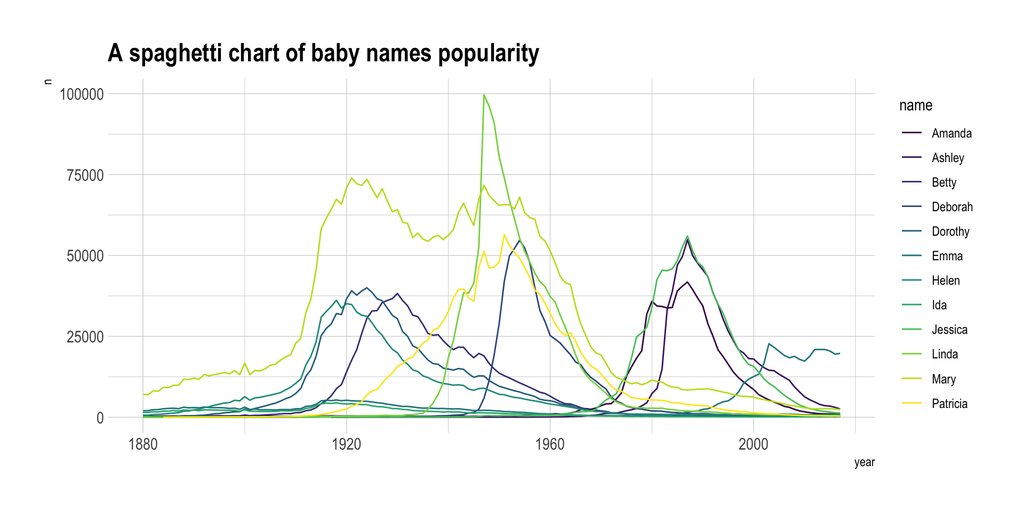

Pour éviter ce problème, vous pouvez faire un graphique par ligne, ou mettre en valeur une ligne en particulier.

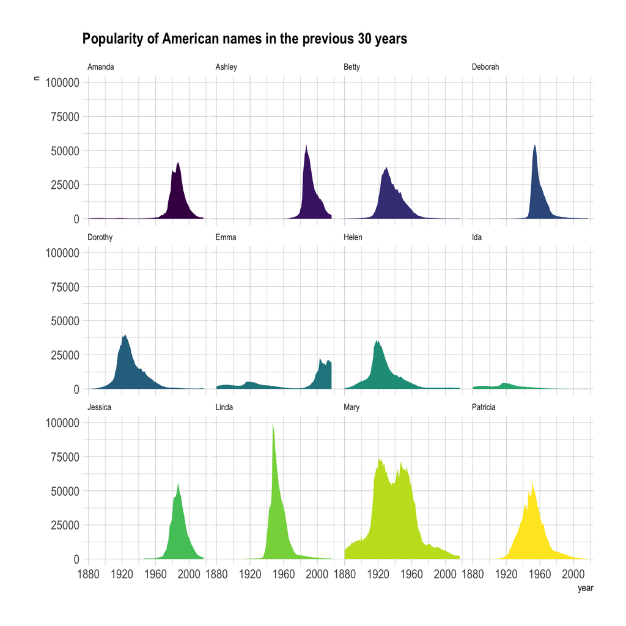

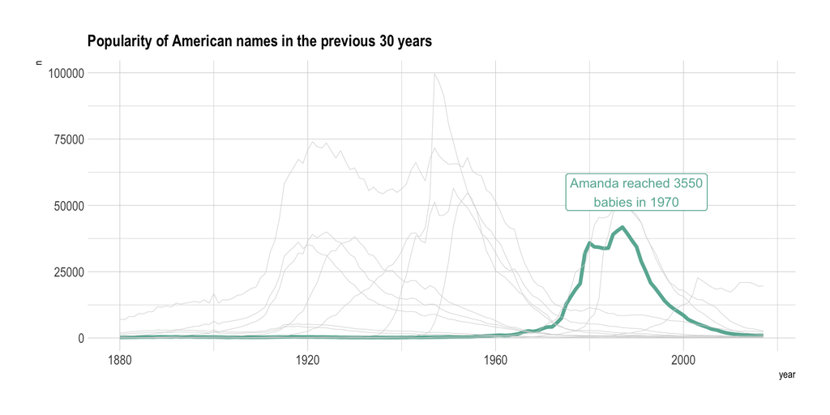

[source des images](https://www.data-to-viz.com/caveat/spaghetti.html)

- Pour les graphiques avec des points, si vous avez trop de points il est difficile de bien l’interpréter.

Pour inclure l’information de la densité en points vous pouvez utiliser la transparence des points, ou montrer la densité en 2D ou 3D

Graphique avec trop de points cachant la densité

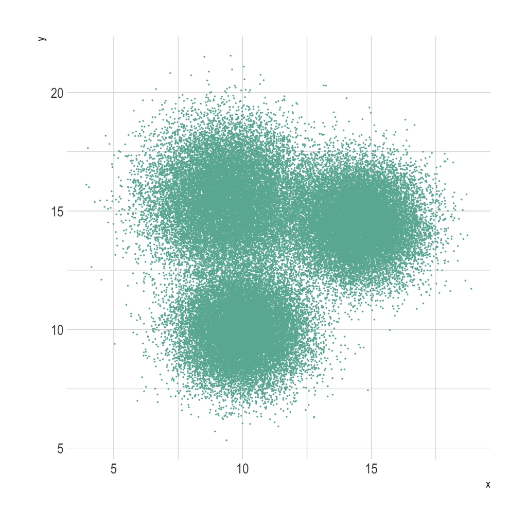

Graphique avec une densité 2D

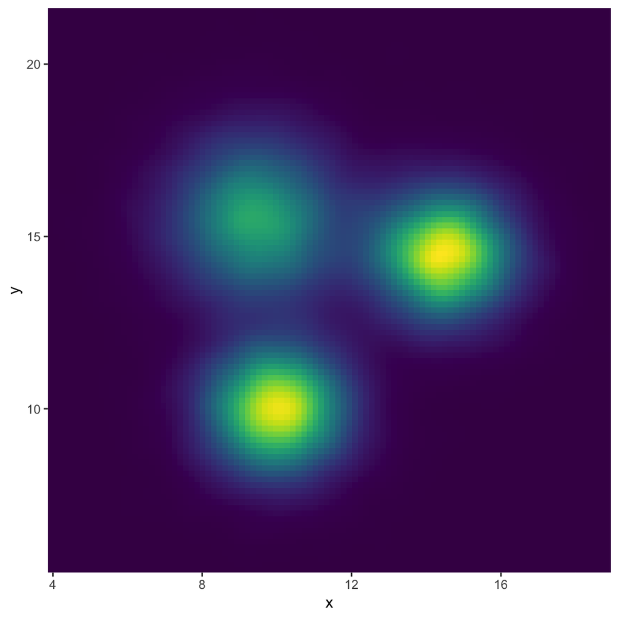

Graphique avec une densité 3D

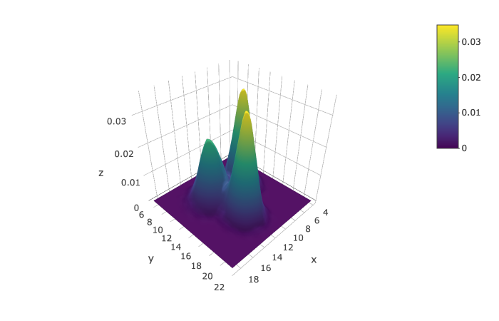

[source des images](https://www.data-to-viz.com/caveat/overplotting.html)

#### 3. Bien utiliser les couleurs

Un avantage de ggplot est qu’il offre une large palette de couleur. Il existe d’ailleurs la libraire `RColorBrewer` qui contient de nombreuses palettes prédéfinies qui vous aideront beaucoup.

Voici toutes les palettes de couleur de `RColorBrewer`

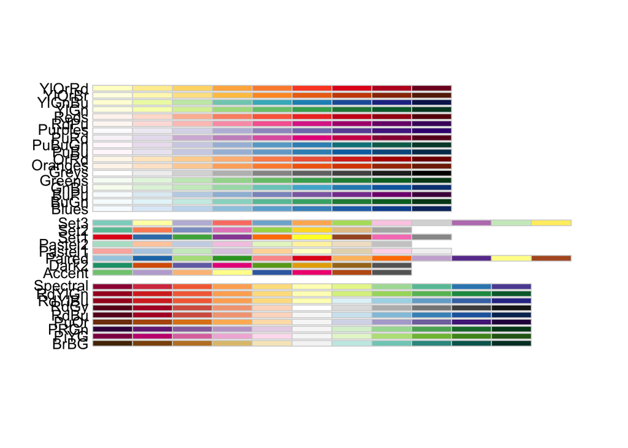

Surtout vous pouvez facilement y sélectionner les palettes de couleurs qui sont aussi visibles pour les daltoniens avec la commande:

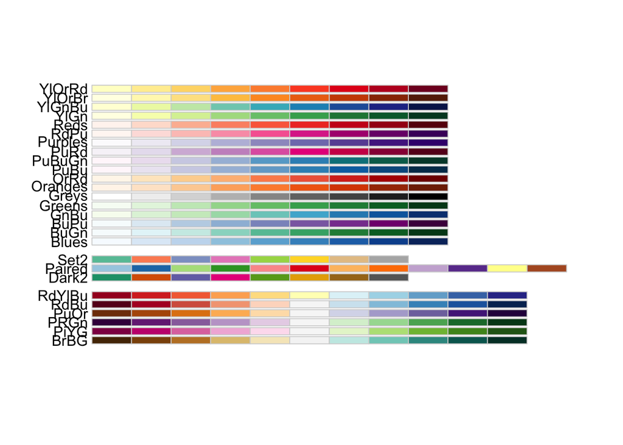

```r
display.brewer.all(colorblindFriendly = TRUE)
```

Maintenant que nous avons accès à toutes ces couleurs, encore faut-il bien les utiliser.

> **Discussion de groupe**

> Discutez avec votre voisin des graphiques suivant.